# Lab 2: Vectors and other data structures

Stat 133, Spring 2018

Kanak Garg

### Getting the Data File

```r
rm(list = ls())
rdata <- "https://github.com/ucb-stat133/stat133-fall-2017/raw/master/data/nba2017-salary-points.RData"
download.file(url = rdata, destfile = 'nba2017-salary-points.RData')
load('nba2017-salary-points.RData')
```

```r
ls()
```

```
## [1] "player"   "points"   "points1"  "points2"  "points3"  "position"
## [7] "rdata"    "salary"   "team"
```

All the data values have the same length with 441 values None of the objects contain any null/NA values in their list. All the data objects except for “team,” are all vectors. Their data types can be determined from above, whether they are a logical vector, character vector or a numeric vector. Team is a factor.

## Manipulating Vectors: Subsetting

- all the even elements in `player`

```r
player[seq(2, length(player), 2)]
```

```
##   [1] "Amir Johnson"            "Demetrius Jackson"
##   [3] "Isaiah Thomas"           "James Young"
##   [5] "Jonas Jerebko"           "Kelly Olynyk"
##   [7] "Terry Rozier"            "Channing Frye"
##   [9] "Deron Williams"          "Edy Tavares"
##  [11] "J.R. Smith"              "Kay Felder"
##  [13] "Kyle Korver"             "LeBron James"
##  [15] "Tristan Thompson"        "Cory Joseph"
##  [17] "DeMar DeRozan"           "Fred VanVleet"
##  [19] "Jonas Valanciunas"       "Lucas Nogueira"
##  [21] "P.J. Tucker"             "Patrick Patterson"
##  [23] "Bojan Bogdanovic"        "Brandon Jennings"
##  [25] "Daniel Ochefu"           "Jason Smith"
##  [27] "Marcin Gortat"           "Otto Porter"
##  [29] "Tomas Satoransky"        "DeAndre' Bembry"
```

[output cut: 95 more lines]

- all the odd elements in `salary`

```r
salary[seq(1, length(salary), 2)]
```

```
##   [1] 26540100  8269663  1410598  6286408  4743000  1223653  3578880
##   [8]  8000000    18255   268029  9700000  1551659 21165675 17638063
##  [15]  2500000  1589640  1577280 14200000  2703960 12000000   874636
##  [22]  1196040 12250000 22116750  1191480 15944154 16957900  7400000
##  [29]   543471  3386598  2708582  8400000 15730338  2500000  1015696
##  [36]   418228  2281605 17100000  1551659 15200000  9607500 10500000
##  [43]  6348759  2368327 10230179   650000  1052342  4000000 10770000
##  [50] 18314532 14153652  1453680   874636 23200000  1643040  1709720
##  [57]  5782450 14000000  2898000 22116750  5782450  2593440   210995
##  [64]  5628000  6000000 22116750  1551659   874060  6000000  3678319
##  [71]   650000 14956522 17200000   102898  5318313  6511628 12000000
##  [78] 12250000 12500000  6000000 24559380 11242000 17000000  4317720
##  [85]  6191000   543471   543471  1375000 17000000  7250000  2613600
##  [92] 15000000    31969 11750000   950000    31969  9000000  9424084
##  [99]  1514160  1025831  8000000   874636  1326960   119494  1562280
```

[output cut: 17 more lines]

- all multiples of 5 (e.g. 5, 10, 15, etc) of `team`

```r
team[seq(5, length(team), 5)]
```

```
##  [1] BOS BOS BOS CLE CLE CLE TOR TOR TOR WAS WAS ATL ATL ATL MIL MIL MIL
## [18] IND IND IND CHI CHI CHI MIA MIA MIA DET DET DET CHO CHO CHO NYK NYK
## [35] NYK ORL ORL ORL PHI PHI PHI BRK BRK BRK GSW GSW GSW SAS SAS SAS HOU
## [52] HOU LAC LAC LAC UTA UTA UTA OKC OKC OKC MEM MEM MEM POR POR POR DEN
## [69] DEN DEN NOP NOP NOP DAL DAL DAL SAC SAC SAC MIN MIN MIN LAL LAL LAL
## [86] PHO PHO PHO
## 30 Levels: ATL BOS BRK CHI CHO CLE DAL DEN DET GSW HOU IND LAC LAL ... WAS
```

- elements in positions 10, 20, 30, 40, etc of `scored`

```r
points[seq(10, length(points), 10)]
```

```
##  [1]  299    6  630  253   24  101 1246  767  815   59 1816  975  374 1105
## [15]  874   57   40   82  299  864  543  709 1742  130  638  639 1104  283
## [29]  100  421  425  551  586  262 1221  150  437  898  470  197  209  425
## [43]  168  444
```

- all the even elements in `team` but this time in reverse order

```r
rev(team[seq(2, length(team), 2)])
```

```
##   [1] PHO PHO PHO PHO PHO PHO PHO LAL LAL LAL LAL LAL LAL LAL LAL MIN MIN
##  [18] MIN MIN MIN MIN MIN SAC SAC SAC SAC SAC SAC SAC DAL DAL DAL DAL DAL
##  [35] DAL DAL DAL NOP NOP NOP NOP NOP NOP NOP DEN DEN DEN DEN DEN DEN DEN
##  [52] POR POR POR POR POR POR POR MEM MEM MEM MEM MEM MEM MEM MEM OKC OKC
##  [69] OKC OKC OKC OKC OKC UTA UTA UTA UTA UTA UTA UTA UTA LAC LAC LAC LAC
##  [86] LAC LAC LAC HOU HOU HOU HOU HOU HOU HOU SAS SAS SAS SAS SAS SAS SAS
## [103] SAS GSW GSW GSW GSW GSW GSW GSW BRK BRK BRK BRK BRK BRK BRK BRK PHI
## [120] PHI PHI PHI PHI PHI PHI ORL ORL ORL ORL ORL ORL ORL ORL NYK NYK NYK
## [137] NYK NYK NYK NYK CHO CHO CHO CHO CHO CHO CHO CHO DET DET DET DET DET
## [154] DET DET MIA MIA MIA MIA MIA MIA MIA CHI CHI CHI CHI CHI CHI CHI CHI
## [171] IND IND IND IND IND IND IND MIL MIL MIL MIL MIL MIL MIL ATL ATL ATL
## [188] ATL ATL ATL ATL WAS WAS WAS WAS WAS WAS WAS TOR TOR TOR TOR TOR TOR
## [205] TOR CLE CLE CLE CLE CLE CLE CLE CLE BOS BOS BOS BOS BOS BOS BOS
## 30 Levels: ATL BOS BRK CHI CHO CLE DAL DEN DET GSW HOU IND LAC LAL ... WAS
```

- players in position Center, of Warriors (GSW)

```r
player[team == "GSW" & position == "C"]
```

```
## [1] "Damian Jones"  "David West"    "JaVale McGee"  "Kevon Looney"
## [5] "Zaza Pachulia"
```

- players of both GSW (warriors) and LAL (lakers)

```r
player[team == "GSW" & team == "LAL"]
```

```
## character(0)
```

- players in positions Shooting Guard and Point Guards, of Lakers (LAL)

```r
player[team == "LAL" & (position == "SG" | position == "PG")]
```

```
## [1] "D'Angelo Russell" "David Nwaba"      "Jordan Clarkson"
## [4] "Nick Young"       "Tyler Ennis"
```

- subset Small Forwards of GSW and LAL

```r
player[team == "LAL" | team == "GSW" & position == "SF"]
```

```
##  [1] "Andre Iguodala"    "Kevin Durant"      "Matt Barnes"
##  [4] "Brandon Ingram"    "Corey Brewer"      "D'Angelo Russell"
##  [7] "David Nwaba"       "Ivica Zubac"       "Jordan Clarkson"
## [10] "Julius Randle"     "Larry Nance Jr."   "Luol Deng"
## [13] "Metta World Peace" "Nick Young"        "Tarik Black"
## [16] "Thomas Robinson"   "Timofey Mozgov"    "Tyler Ennis"
```

- name of the player with largest salary

```r
player[salary == max(salary)]
```

```
## [1] "LeBron James"
```

- name of the player with smallest salary

```r
player[salary == min(salary)]
```

```
## [1] "Edy Tavares"
```

- name of the player with largest number of scored points

```r
player[points == max(points)]
```

```
## [1] "Russell Westbrook"
```

- salary of the player with largest number of points

```r
salary[points == max(points)]
```

```
## [1] 26540100
```

- largest salary of all Centers

```r
max(salary[position == "C"])
```

```
## [1] 26540100
```

- team of the player with the largest number of scored points

```r
team[player == player[points == max(points)]]
```

```
## [1] OKC
## 30 Levels: ATL BOS BRK CHI CHO CLE DAL DEN DET GSW HOU IND LAC LAL ... WAS
```

- name of the player with the largest number of 3-pointers

```r
player[points3 == max(points3)]
```

```
## [1] "Stephen Curry"
```

## Subsetting with Character Vectors

```r
warriors_players <-  player[team == "GSW"]
warriors_salary <- salary[team == "GSW"]
warriors_points <- points[team == "GSW"]
names(warriors_salary) <-  warriors_players
```

### Some plotting

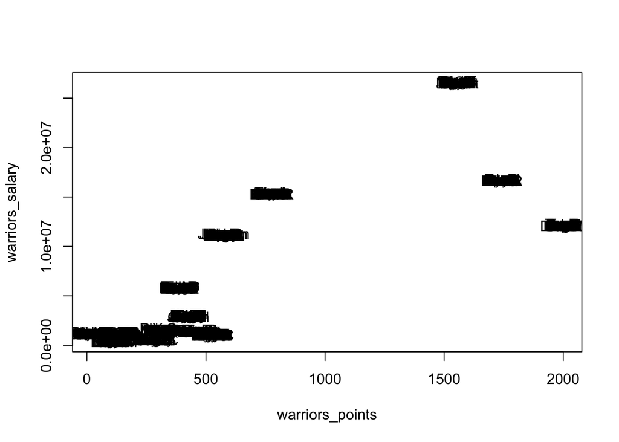

```r
plot(warriors_points, warriors_salary)
text(warriors_points, warriors_salary, labels = abbreviate(player))
```

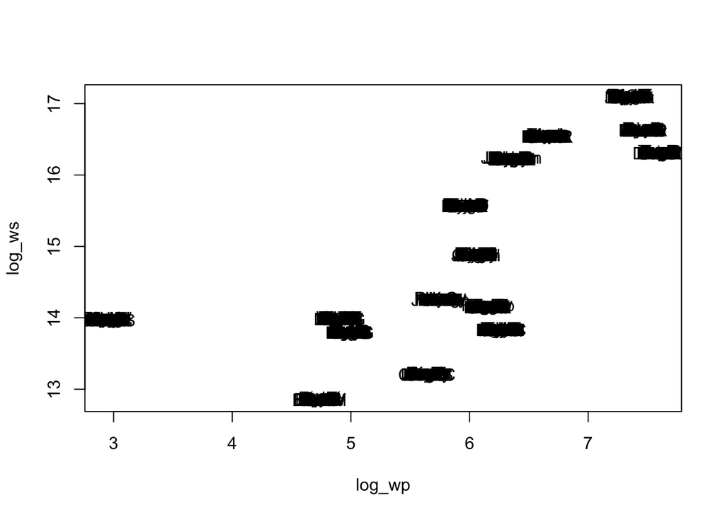

```r
log_wp <- log(warriors_points)
log_ws <- log(warriors_salary)
plot(log_wp, log_ws)
text(log_wp, log_ws, labels = abbreviate(player))
```

## Recycling

`salary` is given in dollars, but what if you need to obtain the salaries in millions of dollars?. Create a new vector `salary_millions` with the converted values in millions of dollars.

```r
salary_millions <- salary/1000000
```

Take the values in `points1`, `points2`, and `points3` and figure out to create a new vector `scored_points` that gives you the same values of `points`.

```r
scored_points = points1 + 2 * points2 + 3* points3
```

### Creating Factors

```r
position_fac <- factor(position)

table(position_fac)
```

```
## position_fac
##  C PF PG SF SG
## 89 89 85 83 95
```

### Manipulating Factors

- positions of Warriors

```r
position_fac[team == "GSW"]
```

```
##  [1] SF C  C  PF SG PF C  SF C  SG SF SG PG PG C
## Levels: C PF PG SF SG
```

- positions of players with salaries > 15 millions

```r
position_fac[salary > 15000000]
```

```
##  [1] C  PF PG SF C  SG SG C  PG C  SF PF C  SF SF SG SF PG C  C  PF SG SF
## [24] PG C  C  SG C  PF SF SG SF PF C  PG PF PF PG C  SF C  PG SF C  PG SG
## [47] PG SF SF C  C  PF PF SG SF C
## Levels: C PF PG SF SG
```

- frequencies (counts) of positions with salaries > 15 millions

```r
table(position_fac[salary > 15000000])
```

```
##
##  C PF PG SF SG
## 17  9  9 13  8
```

- relative frequencies (proportions) of ‘SG’ (Shooting Guards) in each team

```r
table(team[position == "SG"])/table(team[team == team])
```

```
##
##        ATL        BOS        BRK        CHI        CHO        CLE
## 0.07142857 0.20000000 0.26666667 0.26666667 0.26666667 0.20000000
##        DAL        DEN        DET        GSW        HOU        IND
## 0.13333333 0.26666667 0.20000000 0.20000000 0.21428571 0.14285714
##        LAC        LAL        MEM        MIA        MIL        MIN
## 0.20000000 0.20000000 0.20000000 0.28571429 0.28571429 0.14285714
##        NOP        NYK        OKC        ORL        PHI        PHO
## 0.14285714 0.26666667 0.13333333 0.26666667 0.13333333 0.26666667
##        POR        SAC        SAS        TOR        UTA        WAS
## 0.28571429 0.33333333 0.33333333 0.20000000 0.13333333 0.21428571
```

### More Plots

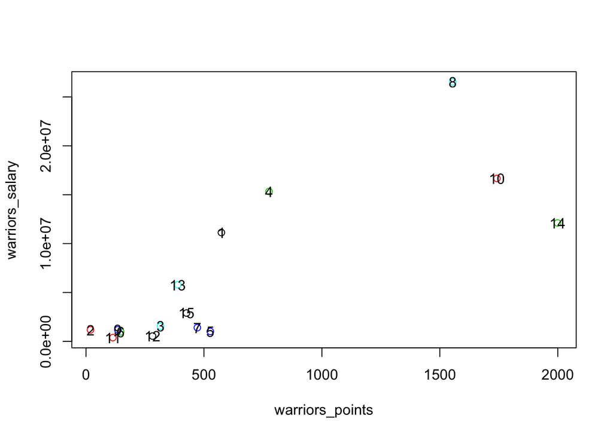

```r
plot(warriors_points, warriors_salary, col = position_fac )
text(warriors_points, warriors_salary)
```